# GroupA_HW3

B. Loletti, S. Tumino, C. Springer, A. Paladino

2023-11-20

# FSDS - Chapter 6

### Exercise 6.12

For the *UN* data file at the book’s website (see Exercise 1.24), construct a multiple regression model predicting Internet using all the other variables. Use the concept of multicollinearity to explain why adjusted $R^2$ is not dramatically greater than when GDP is the sole predictor. Compare the estimated GDP effect in the bivariate model and the multiple regression model and explain why it is so much weaker in the multiple regression model.

*Solution*

```r
UN.data <- read.table("UN.txt", header=T)
```

```r
full.model <- lm(Internet ~ GDP + HDI + GII + Fertility + CO2 + Homicide + Prison, data=UN.data)
summary(full.model)
```

```
##
## Call:
## lm(formula = Internet ~ GDP + HDI + GII + Fertility + CO2 + Homicide +
##     Prison, data = UN.data)
##
## Residuals:
##     Min      1Q  Median      3Q     Max
## -23.819  -5.827  -2.182   7.166  26.354
##
## Coefficients:
##               Estimate Std. Error t value Pr(>|t|)
## (Intercept)  11.158310  38.773097   0.288  0.77526
## GDP           0.440903   0.290680   1.517  0.13856
## HDI          55.851013  46.652218   1.197  0.23952
## GII         -72.428931  25.323061  -2.860  0.00719 **
## Fertility     4.092148   3.065379   1.335  0.19076
## CO2           0.310113   0.654899   0.474  0.63886
## Homicide      0.377324   0.299751   1.259  0.21668
## Prison        0.009091   0.018347   0.495  0.62344
## ---
## Signif. codes:  0 '***' 0.001 '**' 0.01 '*' 0.05 '.' 0.1 ' ' 1
##
## Residual standard error: 10.53 on 34 degrees of freedom
## Multiple R-squared:  0.8477, Adjusted R-squared:  0.8164
## F-statistic: 27.04 on 7 and 34 DF,  p-value: 3.947e-12
```

```r
GDP.model <- lm(Internet ~ GDP, data=UN.data)
summary(GDP.model)
```

```
##
## Call:
## lm(formula = Internet ~ GDP, data = UN.data)
##
## Residuals:
##     Min      1Q  Median      3Q     Max
## -27.130  -5.729   2.124  10.092  20.165
##
## Coefficients:
##             Estimate Std. Error t value Pr(>|t|)
## (Intercept)  26.1341     3.7490   6.971 2.06e-08 ***
## GDP           1.4060     0.1217  11.555 2.55e-14 ***
## ---
## Signif. codes:  0 '***' 0.001 '**' 0.01 '*' 0.05 '.' 0.1 ' ' 1
##
## Residual standard error: 11.95 on 40 degrees of freedom
## Multiple R-squared:  0.7695, Adjusted R-squared:  0.7637
## F-statistic: 133.5 on 1 and 40 DF,  p-value: 2.549e-14
```

```r
ols_vif_tol(full.model)
```

```
##   Variables  Tolerance       VIF
## 1       GDP 0.13616272  7.344154
## 2       HDI 0.09225829 10.839134
## 3       GII 0.13970933  7.157718
## 4 Fertility 0.45599667  2.192998
## 5       CO2 0.38621673  2.589220
## 6  Homicide 0.67942823  1.471826
## 7    Prison 0.51960415  1.924542
```

The increase on the adjusted $R^2$ is not dramatically high because it penalizes the $R^2$ value by the number of parameters. Then, only if the increase of explained variance is significative, the adjusted $R^2$ will increase dramatically. From the Variance Inflation Factor (VIF) we can see that the covariate HDI has value greater than 10, which suggest the multicollinearity. Similarly the covariates GDP and GII have a really high value which means that most information could be obtained from the other informations.

### Exercise 6.14

The dataset *Crabs2* at the book’s website comes from a study of factors that affect sperm traits of male horseshoe crabs. A response variable, SpermTotal, is the log of the total number of sperm in an ejaculate. It has $\bar{y} = 19.3$ and $s = 2.0$. The two explanatory variables used in the R output are the horseshoe crab’s carapace width (CW, mean 18.6 cm, standard deviation 3.0 cm), which is a measure of its size, and color (1 = dark, 2 = medium, 3 = light), which is a measure of adult age, darker ones being older. (a) Using the results shown, write the prediction equation and interpret the parameter estimates. (b) Explain the differences in what is tested with the F statistic (i) for the overall model, (ii) for the factor(Color) effect, (iii) for the interaction term. Interpret each.

```
##
## Call:
## lm(formula = SpermTotal ~ CW + factor(Color), data = Crabs2)
##
## Residuals:
##     Min      1Q  Median      3Q     Max
## -4.9180 -1.0040  0.0444  1.0342  4.2392
##
## Coefficients:
##                Estimate Std. Error t value Pr(>|t|)
## (Intercept)    11.35896    0.63776  17.811  < 2e-16 ***
## CW              0.39115    0.03357  11.654  < 2e-16 ***
## factor(Color)2  0.80811    0.24563   3.290  0.00114 **
## factor(Color)3  1.14879    0.27105   4.238 3.15e-05 ***
## ---
## Signif. codes:  0 '***' 0.001 '**' 0.01 '*' 0.05 '.' 0.1 ' ' 1
##
## Residual standard error: 1.585 on 254 degrees of freedom
## Multiple R-squared:  0.3941, Adjusted R-squared:  0.3869
## F-statistic: 55.06 on 3 and 254 DF,  p-value: < 2.2e-16
```

```
## Anova Table (Type II tests)
##
## Response: SpermTotal
##                  Sum Sq  Df  F value    Pr(>F)
## CW               341.25   1 136.3607 < 2.2e-16 ***
## factor(Color)     47.93   2   9.5757 9.812e-05 ***
## CW:factor(Color)   7.61   2   1.5198    0.2207
## Residuals        630.65 252
## ---
## Signif. codes:  0 '***' 0.001 '**' 0.01 '*' 0.05 '.' 0.1 ' ' 1
```

*Solution*

1. $y = \beta_0 + \beta_1x_{CW} + \beta_2x_{medium} + \beta_3x_{light}$ The increase of the carapace width leads to the increase of the amount of the sperm. Therefore the lighter the color is, the more is the increase of the amount.
2. The analysis of variance (ANOVA) test if the difference in the means are the same. From the results we can see that the CW and the color have a small p-value, then null hypotesis is rejected and then we have an increase of the amount of the sperm on the increase of CW and Color. The interaction doesn’t have a big effect in the prediction.

### Exercise 6.30

When the values of y are multiplied by a constant c, from their formulas, show that $s_y$ and $\hat\beta_1$ in the bivariate linear model are also then multiplied by c. Thus, show that $r = \hat\beta_1(s_x/s_y)$ does not depend on the units of measurement.

*Solution*

b0 = mean(X) + b1 mean(Y)

$y = \beta_0 + \beta_1x_1 + e$ with $e$ ~ $N(0, \sigma^2X^TX)$ then $y$ ~ $N(\beta_0 + \beta_1x_1, \sigma^2X^TX)$

$cy = c(\beta_0 + \beta_1x_1 + e)$ and then $y$ ~ $N(c\beta_0 + c\beta_1x_1, c^2\sigma^2X^TX)$ or $\rho \frac{s_{cy}}{s_x} = \rho \frac{c \cdot s_y}{s_x}$

$\hat\beta_1 = \frac{cov(x, y)}{Var(x)} = \rho \frac{c \cdot s_y}{s_x}$ then $\frac{cov(x, cy)}{Var(x)} = c \frac{cov(x, y)}{Var(x)} = c\hat\beta_1$

from this two results we obtain

$\rho = \hat\beta_1 (\frac{s_x}{s_{y^*}}) = c \hat\beta_1 (\frac{s_x}{c s_{y}}) = \hat\beta_1 (\frac{s_x}{s_y})$ with $y^* = cy$

### Exercise 6.42

You can fit the quadratic equation $E(Y) = \beta_0 +\beta_1x+\beta_2x^2$ by fitting a multiple regression model with $x_1 = x$ and $x_2 = x^2$. (a) Simulate 100 independent observations from the model $Y = 40.0−5.0x+0.5x^2 + e$, where X has a uniform distribution over $[0, 10]$ and $ϵ ∼ N(0, 1)$. Plot the data and fit the quadratic model. Report how the fitted equation compares with the true relationship. (b) Find the correlation between x and y and explain why it is so weak even though the plot shows a strong relationship with a large $R^2$ value for the quadratic model.

*Solution*

```r
x <- sort(runif(100, 0, 10))
e <- rnorm(100)
Y <- 40 - 5*x + 0.5*x^2 + e
```

```r
model <- lm(Y~x + I(x^2))
summary(model)
```

```
##
## Call:
## lm(formula = Y ~ x + I(x^2))
##
## Residuals:
##     Min      1Q  Median      3Q     Max
## -2.9511 -0.6233 -0.0691  0.4966  2.8227
##
## Coefficients:
##             Estimate Std. Error t value Pr(>|t|)
## (Intercept) 39.20536    0.36113  108.56   <2e-16 ***
## x           -4.75979    0.15037  -31.65   <2e-16 ***
## I(x^2)       0.48296    0.01379   35.03   <2e-16 ***
## ---
## Signif. codes:  0 '***' 0.001 '**' 0.01 '*' 0.05 '.' 0.1 ' ' 1
##
## Residual standard error: 0.9211 on 97 degrees of freedom
## Multiple R-squared:  0.9324, Adjusted R-squared:  0.931
## F-statistic: 668.6 on 2 and 97 DF,  p-value: < 2.2e-16
```

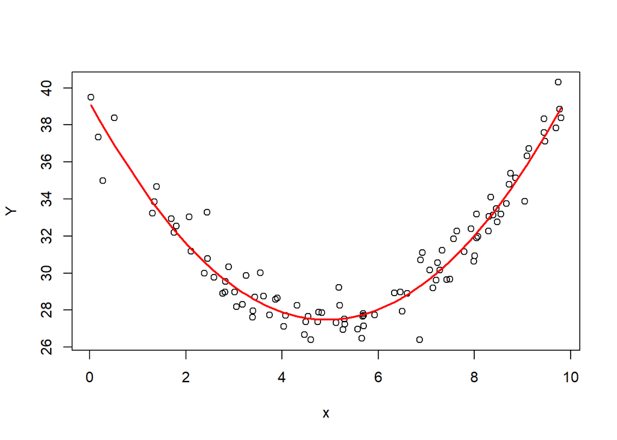

```r
b0 <- model$coefficients[1]
b1 <- model$coefficients[2]
b2 <- model$coefficients[3]

plot(x, Y)
lines(x, b0 + b1*x + b2*x^2, col="red", lwd=2)
```

1. With the quadratic model we have that the predicted line is similar perfectly fitting the data. The predicted parameters are very near to the real ones.
2. The correlation is really small because the data are symmetric and then there is not a linear relationship

```r
cor(x, Y)
```

```
## [1] 0.2770082
```

### Exercise 6.52

F statistics have alternate expressions in terms of $R^2$ values.

1. Show that for testing $H_0: \beta_1 = ⋯ = \beta_p = 0$, $F = \frac{(TSS − SSE)/p}{SSE/[n − (p + 1)]}$ is equivalently $\frac{R^2/p}{(1 − R^2)/[n − (p + 1)]}$ Explain why larger values of $R^2$ yield larger values of F.
2. Show that for comparing nested linear models, $F = \frac{(SSE_0 − SSE_1)/(p_1 − p_0)}{SSE_1/[n − (p_1 + 1)]} = \frac{(R^2_1 − R^2_0)/(p_1 − p_0)}{(1 − R^2_1)/[n − (p_1 + 1)]}$

*Solution*

1. $R^2 = \frac{RSS}{TSS} = \frac{TSS - SSE}{TSS}$ $1 - R^2 = 1 - (1 - \frac{SSE}{TSS}) = \frac{SSE}{TSS}$ $F = \frac{R^2/p}{(1 − R^2)/[n − (p + 1)]} = \frac{\frac{TSS - SSE}{TSS}/p}{(\frac{SSE}{TSS})/[n − (p + 1)]} = \frac{(TSS − SSE)/p}{SSE/[n − (p + 1)]}$ A larger value of $R^2$ yield a larger value of F because the numerator is the value of $R^2$ itself multiplied to $n - p - 1$, while the denominator is nearer to zero the larger is the value of $R^2$.

```r
p <- 12
n <- 23
TSS <- 65
SSE <- 52
R2 <- 1 - SSE/TSS

c(((TSS - SSE)/p)/(SSE/(n-p-1)), (R2/p)/((1-R2)/(n-p-1)))
```

```
## [1] 0.2083333 0.2083333
```

2. $R^2 = 1 - \frac{SSE}{TSS}$ $1 - R^2 = 1 - (1 - \frac{SSE}{TSS}) = \frac{SSE}{TSS}$

   $TSS_0 = TSS_1 = TSS$ because it is a nested model

   $F = \frac{(R^2_1 − R^2_0)/(p_1 − p_0)}{(1 − R^2_1)/[n − (p_1 + 1)]} = \frac{((1 -\frac{SSE_1}{TSS}) - (1 -\frac{SSE_0}{TSS}))/(p_1-p_0)}{\frac{SSE_1}{TSS}/(n-p_1-1)} = \frac{(SSE_0 - SSE_1)/(p_1-p_0)}{SSE_1/(n-p_1-1)}$

```r
p0 <- 18
p1 <- 27
n <- 23
TSS <- 65
SSE0 <- 50
SSE1 <- 34
R21 <- 1 - SSE1/TSS
R20 <- 1 - SSE0/TSS

c( ((SSE0 - SSE1)/(p1 - p0))/(SSE1/(n-p1-1)), ((R21 - R20)/(p1 - p0))/((1-R21)/(n-p1-1)))
```

```
## [1] -0.2614379 -0.2614379
```

# FSDS - Chapter 7

### Exercise 7.4

Randomly sample 30 $X$ observations from a uniform in the interval $(-4,4)$ and conditional on $X = x$, 30 normal observations with $E(Y) = 3.5x^3 − 20x^2 + 0.5x + 20$ and $σ = 30$. Fit polynomial normal GLMs of lower and higher order than that of the true relationship. Which model would you suggest? Repeat the same task for $E(Y) = 0.5x^3 − 20x^2 + 0.5x + 20$ (same $\sigma$) several times. What do you observe? Which model would you suggest now?

*Solution*

```r
set.seed(100)
n <- 30
x <- sort(runif(n, -4, 4))
eps <- rnorm(n, 0, 30)
y <- 3.5 * x^3 - 20 * x^2 + 0.5 * x + 20 + eps
data <- data.frame(x = rep(x, each= 30), y = y)
```

```r
mod1 <- glm(y ~ x + I(x^2), family = gaussian, data=data)
AIC(mod1)
```

```
## [1] 10623.5
```

```r
mod2 <- glm(y ~ x + I(x^2) + I(x^3) + I(x^4), family = gaussian, data=data)
AIC(mod2)
```

```
## [1] 10627.5
```

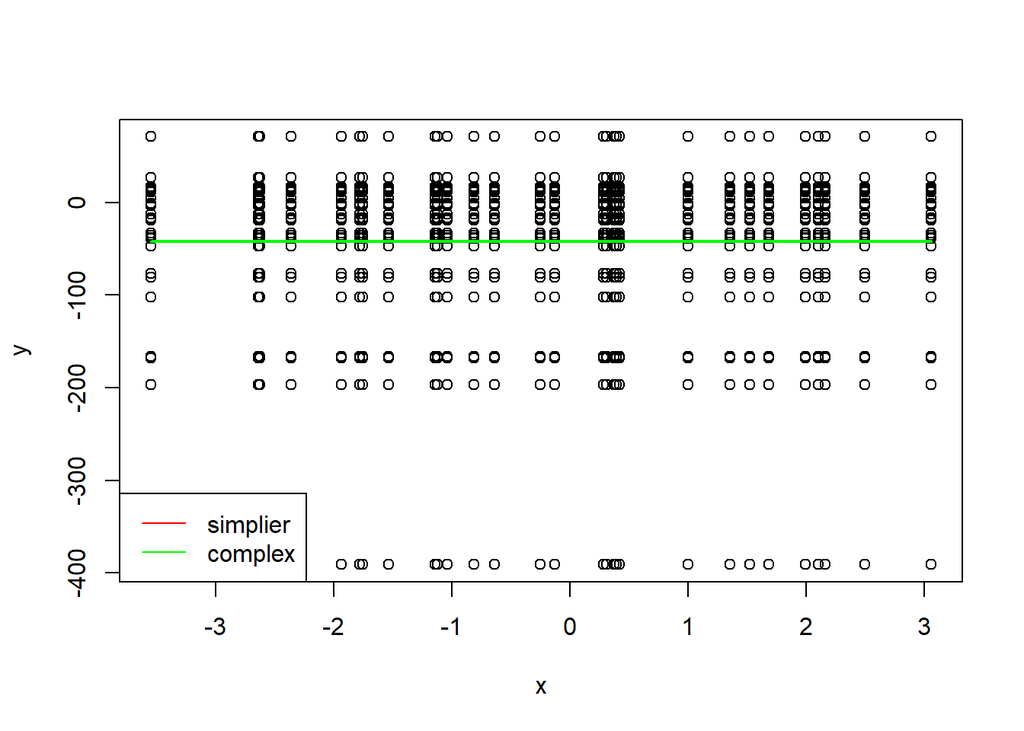

The red curve is the estimate from the simpler method, while the green one is from the more complex one. Here we can see a not significant change in the AIC coefficient, indicating that the simplest model would be more appropriate.

Let’s see the other case:

```r
set.seed(100)
n <- 30
x <- sort(runif(n, -4, 4))
eps <- rnorm(n, 0, 30)
y <- .5 * x^3 - 20 * x^2 + 0.5 * x + 20 + eps
data <- data.frame(x = rep(x, each= 30), y = y)
```

```r
mod1 <- glm(y ~ x + I(x^2), family = gaussian, data=data)
AIC(mod1)
```

```
## [1] 10233.7
```

```r
mod2 <- glm(y ~ x + I(x^2) + I(x^3) + I(x^4), family = gaussian, data=data)
AIC(mod2)
```

```
## [1] 10237.7
```

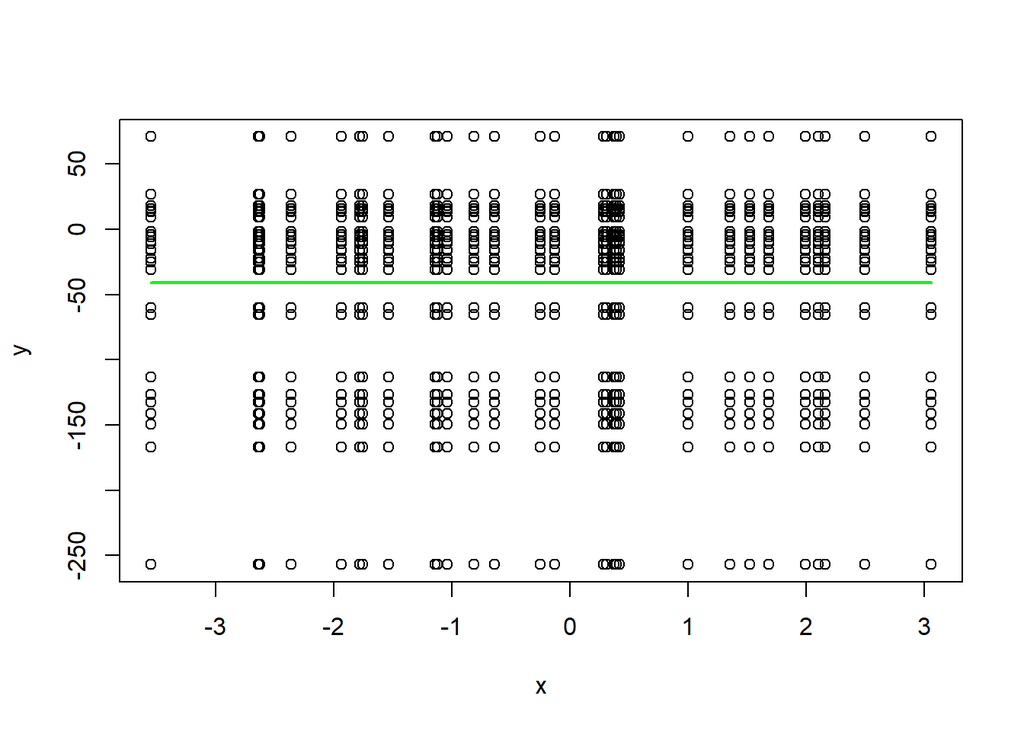

Let’s repeat this task several times and check how the difference between the two AIC’s behave:

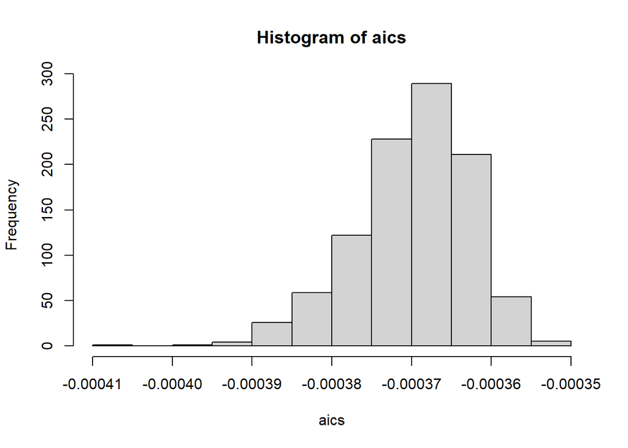

```r
m=1000
aics <- array(0, dim = m)

for (i in 1:m) {
  n <- 30
  x <- sort(runif(n, -4, 4))
  eps <- rnorm(n, 0, 30)
  y <- .5 * x^3 - 20 * x^2 + 0.5 * x + 20 + eps
  data <- data.frame(x = rep(x, each= 30), y = y)
  mod1 <- glm(y ~ x + I(x^2), family = gaussian, data=data)
  mod2 <- glm(y ~ x + I(x^2) + I(x^3) + I(x^4), family = gaussian, data=data)
  aics[i] <- (AIC(mod1) - AIC(mod2))/AIC(mod1)
}
hist(aics)
```

In this case the AIC coefficients and the plot indicates that the two models are very similar. Following Occam’s razor principle we opt for the simpler method, i.e. the one with less parameters.

### Exercise 7.20

In the *Crabs* data file introduced in Section 7.4.2, the variable y indicates whether a female horseshoe crab has at least one satellite (1 = yes, 0 = no). (a) Fit a main-effects logistic model using weight and categorical color as explanatory variables. Conduct a significance test for the color effect, and construct a 95% confidence interval for the weight effect. (b) Fit the model that permits interaction between color as a factor and weight in their effects, showing the estimated effect of weight for each color. Test whether this model provides a significantly better fit. (c) Use AIC to determine which models seem most sensible among the models with (i) interaction, (ii) main effects, (iii) weight as the sole predictor, (iv) color as the sole predictor, and (v) the null model.

*Solution*

```r
crabs <- read.table("crabs.txt", header = TRUE)
crabs$color <- as.factor(crabs$color)
model1 <- glm(y ~ weight + color, data = crabs, family = "binomial")
summary(model1)
```

```
##
## Call:
## glm(formula = y ~ weight + color, family = "binomial", data = crabs)
##
## Coefficients:
##             Estimate Std. Error z value Pr(>|z|)
## (Intercept)  -3.2572     1.1985  -2.718  0.00657 **
## weight        1.6928     0.3888   4.354 1.34e-05 ***
## color2        0.1448     0.7365   0.197  0.84410
## color3       -0.1861     0.7750  -0.240  0.81019
## color4       -1.2694     0.8488  -1.495  0.13479
## ---
## Signif. codes:  0 '***' 0.001 '**' 0.01 '*' 0.05 '.' 0.1 ' ' 1
##
## (Dispersion parameter for binomial family taken to be 1)
##
##     Null deviance: 225.76  on 172  degrees of freedom
## Residual deviance: 188.54  on 168  degrees of freedom
## AIC: 198.54
##
## Number of Fisher Scoring iterations: 4
```

```r
model2 <- glm(y ~ weight , data = crabs, family = "binomial")
summary(model2)
```

```
##
## Call:
## glm(formula = y ~ weight, family = "binomial", data = crabs)
##
## Coefficients:
##             Estimate Std. Error z value Pr(>|z|)
## (Intercept)  -3.6947     0.8802  -4.198 2.70e-05 ***
## weight        1.8151     0.3767   4.819 1.45e-06 ***
## ---
## Signif. codes:  0 '***' 0.001 '**' 0.01 '*' 0.05 '.' 0.1 ' ' 1
##
## (Dispersion parameter for binomial family taken to be 1)
##
##     Null deviance: 225.76  on 172  degrees of freedom
## Residual deviance: 195.74  on 171  degrees of freedom
## AIC: 199.74
##
## Number of Fisher Scoring iterations: 4
```

We compare the residual deviances and check if the difference could have been reasonably generated by a Chi-squared distribution with 3 degrees of freedom:

```r
1-pchisq(195.74-188.54,3)
```

```
## [1] 0.06578905
```

We get a borderline result that points towards the variable color not being statistically significant so we select the model with only the covariate weight.

For constructing the confidence interval for the variable weight we can use the data from the summary:

```r
estimate <- 1.6928
se <- 0.3888
confidence_level <- 0.95
critical_value <- qnorm((confidence_level + 1) / 2)
margin_of_error <- critical_value * se
confidence_interval <- c(estimate - margin_of_error, estimate + margin_of_error)
confidence_interval
```

```
## [1] 0.930766 2.454834
```

Since 0 isn’t inside the confidence interval we can infer that the weight variable is statistically significant for the model.

```r
model_main <- glm(y ~ weight + color, data = crabs, family = "binomial")
model_interaction <- glm(y ~ weight * color, data = crabs, family = "binomial")
lr_test <- lrtest(model_main, model_interaction)
print(lr_test)
```

```
## Likelihood ratio test
##
## Model 1: y ~ weight + color
## Model 2: y ~ weight * color
##   #Df  LogLik Df Chisq Pr(>Chisq)
## 1   5 -94.271
## 2   8 -90.828  3 6.886    0.07562 .
## ---
## Signif. codes:  0 '***' 0.001 '**' 0.01 '*' 0.05 '.' 0.1 ' ' 1
```

With a p-value of 0.07562, the evidence against the null hypothesis is not strong enough to reject it, although it’s pretty close to the threshold, meaning there is no strong evidence to suggest that adding interaction terms significantly improves the model fit.

```r
model_interaction <- glm(y ~ weight * color, data = crabs, family = "binomial")
model_main <- glm(y ~ weight + color, data = crabs, family = "binomial")
model_weight <- glm(y ~ weight, data = crabs, family = "binomial")
model_color <- glm(y ~ color, data = crabs, family = "binomial")
model_null <- glm(y ~ 1, data = crabs, family = "binomial")
aics <- c(AIC(model_interaction), AIC(model_main), AIC(model_weight), AIC(model_color), AIC(model_null))
aics
```

```
## [1] 197.6563 198.5423 199.7371 220.0608 227.7585
```

We can see that the biggest gap in AIC score is between the model having weight as covariate and the one having color. We can also see that the model having the lowest AIC score is the one taking into consideration the interaction between weight and color.

### Exercise 7.26

A headline in The Gainesville Sun (Feb. 17, 2014) proclaimed a worrisome spike in shark attacks in the previous two years. The reported total number of shark attacks in Florida per year from 2001 to 2013 were 33, 29, 29, 12, 17, 21, 31, 28, 19, 14, 11, 26, 23. Are these counts consistent with a null Poisson model? Explain, and compare aspects of the Poisson model and negative binomial model fits.

```r
observed.counts<-c(33, 29, 29, 12, 17, 21, 31, 28, 19, 14, 11, 26, 23)
lambda_value<-sum(observed.counts)/length(observed.counts)
expected_counts <- dpois(observed.counts, lambda = lambda_value)
chi_square <- chisq.test(observed.counts, p = expected_counts / sum(expected_counts))
chi_square
```

```
##
##  Chi-squared test for given probabilities
##
## data:  observed.counts
## X-squared = 329.31, df = 12, p-value < 2.2e-16
```

```r
critical_value <- qchisq(1 - 0.05, 12)
critical_value
```

```
## [1] 21.02607
```

By comparing the critical_value with the chi_square value we see that 329.32>21.026, which means that we have to reject the null hypothesis that the data follow a Poisson distribution.

```r
y <- c(33, 29, 29, 12, 17, 21, 31, 28, 19, 14, 11, 26, 23)
x <- 2001:2013

library(MASS)
```

```r
fit <- glm(y ~ x, family = poisson(link = "log"))
summary(fit)
```

```
##
## Call:
## glm(formula = y ~ x, family = poisson(link = "log"))
##
## Coefficients:
##             Estimate Std. Error z value Pr(>|z|)
## (Intercept) 66.89554   31.46400   2.126   0.0335 *
## x           -0.03178    0.01568  -2.027   0.0427 *
## ---
## Signif. codes:  0 '***' 0.001 '**' 0.01 '*' 0.05 '.' 0.1 ' ' 1
##
## (Dispersion parameter for poisson family taken to be 1)
##
##     Null deviance: 31.392  on 12  degrees of freedom
## Residual deviance: 27.267  on 11  degrees of freedom
## AIC: 95.003
##
## Number of Fisher Scoring iterations: 4
```

```r
fit2 <- glm.nb(y ~ x)
summary(fit2)
```

```
##
## Call:
## glm.nb(formula = y ~ x, init.theta = 20.15274625, link = log)
##
## Coefficients:
##             Estimate Std. Error z value Pr(>|z|)
## (Intercept) 64.26589   45.75078   1.405    0.160
## x           -0.03047    0.02280  -1.337    0.181
##
## (Dispersion parameter for Negative Binomial(20.1527) family taken to be 1)
##
##     Null deviance: 15.391  on 12  degrees of freedom
## Residual deviance: 13.522  on 11  degrees of freedom
## AIC: 92.879
##
## Number of Fisher Scoring iterations: 1
##
##
##               Theta:  20.2
##           Std. Err.:  15.7
##
##  2 x log-likelihood:  -86.879
```

```r
chi <- summary(fit)$null.deviance - summary(fit)$deviance
p_value <- 1 - pchisq(chi, df = 1)
p_value
```

```
## [1] 0.04223352
```

```r
chi <- summary(fit2)$null.deviance - summary(fit2)$deviance
p_value <- 1 - pchisq(chi, df = 1)
p_value
```

```
## [1] 0.1716756
```

From the summaries we can see that the Poisson model is a good fit w.r.t the null model because the difference of deviance is statistically significant greater than a value from a $\chi^2_{p-p_0}$. However the negative binomial model is better as a null model because the difference of deviance is not statistically significant greater than a value from a $\chi^2_{p-p_0}$. The coefficients are similar and the AIC suggest that the negative binomial model is better.

# DAAG - Chapter 8

### Exercise 6

As in the previous exercise, the function poissonsim() allows for experimentation with Poisson regression. In particular, poissonsim() can be used to simulate Poisson responses with log-rates equal to a + bx, where a and b are fixed values by default.

1. Simulate 100 Poisson responses using the model $\log\lambda = 2 − 4x$ for x = 0, 0.01, 0.02 . . . , 1.0. Fit a Poisson regression model to these data, and compare the estimated coefficients with the true coefficients. How well does the estimated model predict future observations?
2. Simulate 100 Poisson responses using the model $\log\lambda = 2 − bx$ where b is normally distributed with mean 4 and standard deviation 5. [Use the argument $slope.sd=5$ in the poissonsim() function.] How do the results using the poisson and quasipoisson families differ?

*Solution*

```r
library(DAAG)

simulated <- poissonsim(seq(0, 1, length=100), 2, -4)

fit <- glm(simulated$y ~ simulated$x, family = poisson(link = "log"))
summary(fit)
```

```
##
## Call:
## glm(formula = simulated$y ~ simulated$x, family = poisson(link = "log"))
##
## Coefficients:
##             Estimate Std. Error z value Pr(>|z|)
## (Intercept)   1.9748     0.1098   17.99   <2e-16 ***
## simulated$x  -3.9454     0.3522  -11.20   <2e-16 ***
## ---
## Signif. codes:  0 '***' 0.001 '**' 0.01 '*' 0.05 '.' 0.1 ' ' 1
##
## (Dispersion parameter for poisson family taken to be 1)
##
##     Null deviance: 273.47  on 99  degrees of freedom
## Residual deviance: 100.87  on 98  degrees of freedom
## AIC: 271.23
##
## Number of Fisher Scoring iterations: 5
```

```r
test <- as.list(poissonsim(seq(0, 1, length=100), 2, -4))
x <- test$x
y <- test$y

pred <- predict(fit, newdata = data.frame(x), type = "response")
sum((y - pred)^2) / length(y)
```

```
## [1] 1.533898
```

From the summary we can see that the estimated coefficients are very close to the true coefficients. The model predicts future observations correctly.

```r
b <- rnorm(1, 4, 5)
b
```

```
## [1] 5.778005
```

```r
simulated <- poissonsim(seq(0, 1, length=100), 2, -b, slope.sd = 5)

fit.poisson <- glm(simulated$y ~ simulated$x, family = poisson(link = "log"))
fit.quasi   <- glm(simulated$y ~ simulated$x, family = quasipoisson(link = "log"))
summary(fit.poisson)
```

```
##
## Call:
## glm(formula = simulated$y ~ simulated$x, family = poisson(link = "log"))
##
## Coefficients:
##             Estimate Std. Error z value Pr(>|z|)
## (Intercept)  2.65435    0.04522   58.70   <2e-16 ***
## simulated$x  1.14890    0.06861   16.75   <2e-16 ***
## ---
## Signif. codes:  0 '***' 0.001 '**' 0.01 '*' 0.05 '.' 0.1 ' ' 1
##
## (Dispersion parameter for poisson family taken to be 1)
##
##     Null deviance: 19536  on 99  degrees of freedom
## Residual deviance: 19246  on 98  degrees of freedom
## AIC: 19439
##
## Number of Fisher Scoring iterations: 9
```

```r
summary(fit.quasi)
```

```
##
## Call:
## glm(formula = simulated$y ~ simulated$x, family = quasipoisson(link = "log"))
##
## Coefficients:
##             Estimate Std. Error t value Pr(>|t|)
## (Intercept)    2.654      1.918   1.384    0.169
## simulated$x    1.149      2.910   0.395    0.694
##
## (Dispersion parameter for quasipoisson family taken to be 1798.893)
##
##     Null deviance: 19536  on 99  degrees of freedom
## Residual deviance: 19246  on 98  degrees of freedom
## AIC: NA
##
## Number of Fisher Scoring iterations: 9
```

As expected, the coefficients found from the two models are the same while the standard errors, and then t and p, are different. The p-values in the quasi-poisson model suggest that the variable x is not statistically significant for the model.